# Introduction to promor

### Introduction

- `promor` is a user-friendly, comprehensive R package that combines proteomics data analysis with machine learning-based modeling.
- `promor` streamlines differential expression analysis of **label-free quantification (LFQ)** proteomics data and building predictive models with top protein candidates.
- `promor` provides a range of quality control and visualization tools at the protein level to analyze label-free proteomics data.
- Input files for `promor` are a [proteinGroups.txt](https://raw.githubusercontent.com/caranathunge/promor_example_data/main/pg1.txt) file produced by [**MaxQuant**](https://maxquant.org) or a [standard input file](https://raw.githubusercontent.com/caranathunge/promor_example_data/main/st.txt) containing a quantitative matrix of protein intensities and an [expDesign.txt](https://raw.githubusercontent.com/caranathunge/promor_example_data/main/ed1.txt) file containing the experimental design of your proteomics data.
- The standard input file should be a tab-delimited text file. Proteins or protein groups should be indicated by rows and samples by columns. Protein names should be listed in the first column and you may use a column name of your choice for the first column. The remaining sample column names should match the sample names indicated by the mq_label column in the expDesign.txt file.

### Installation

You can install the development version of promor from [GitHub](https://github.com/) with:

```r
# install devtools, if you haven't already:
install.packages("devtools")

# install promor from github
devtools::install_github("caranathunge/promor")
```

### Proteomics data analysis with promor

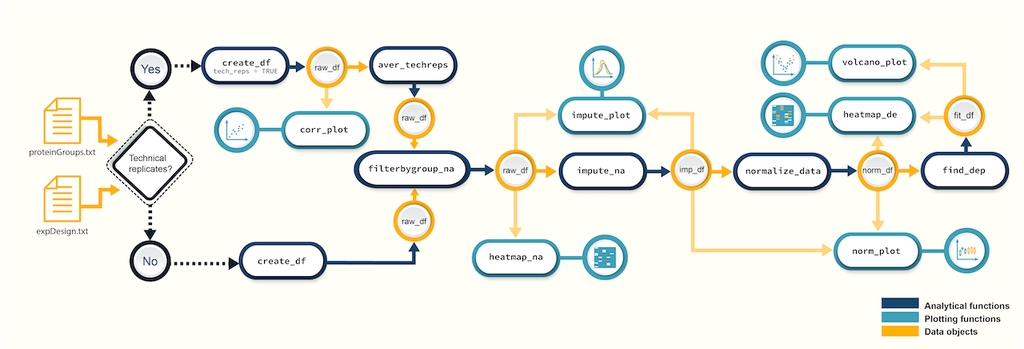

*Figure 1. A schematic diagram of suggested workflows for proteomics data analysis with promor.*

#### Example

Here is a minimal working example showing how to identify differentially expressed proteins between two conditions using `promor` in five simple steps.

We use a previously published data set from [Cox et al. (2014)](https://europepmc.org/article/MED/24942700#id609082) (PRIDE ID: PXD000279).

```r
# Load promor
library(promor)

# Create a raw_df object with the files provided in this github account.
raw <- create_df(
  prot_groups = "https://raw.githubusercontent.com/caranathunge/promor_example_data/main/pg1.txt",
  exp_design = "https://raw.githubusercontent.com/caranathunge/promor_example_data/main/ed1.txt"
)

# Filter out proteins with high levels of missing data in either condition/group
raw_filtered <- filterbygroup_na(raw)

# Impute missing data and create an imp_df object.
imp_df <- impute_na(raw_filtered)

# Normalize data and create a norm_df object
norm_df <- normalize_data(imp_df)

# Perform differential expression analysis and create a fit_df object
fit_df <- find_dep(norm_df)
```

Lets take a look at the results using a volcano plot.

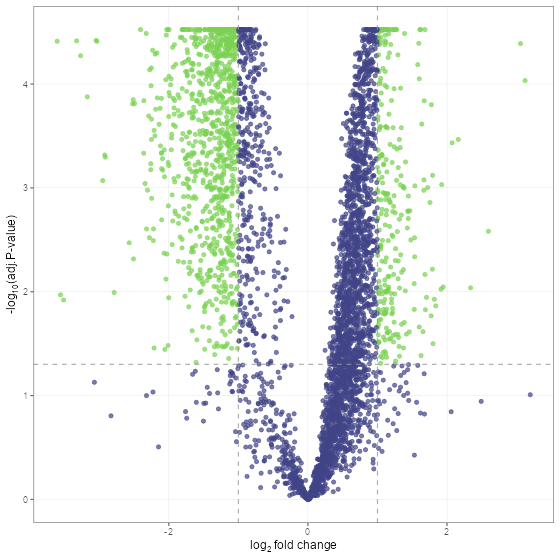

```r
volcano_plot(fit_df, text_size = 5)
```

### Modeling with promor

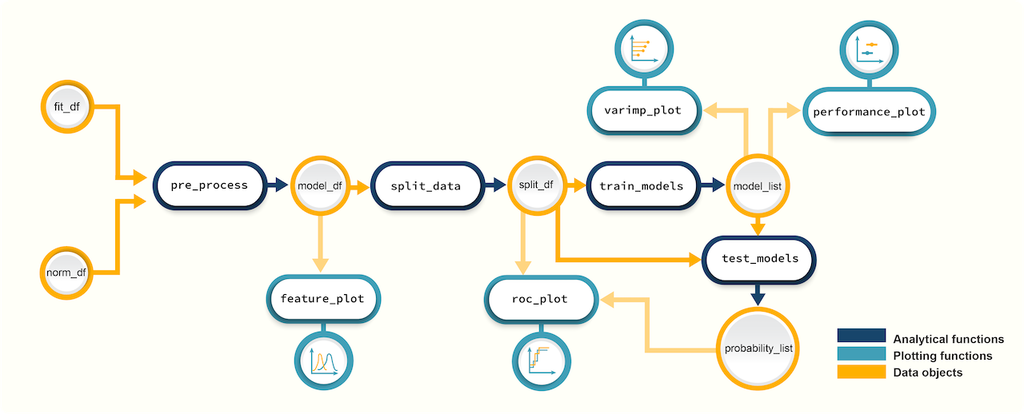

*Figure 2. A schematic diagram of suggested workflows for building predictive models with promor.*

#### Example

The following minimal working example shows you how to use your results from differential expression analysis to build machine learning-based predictive models using *promor*.

We use a previously published data set from [Suvarna et al. (2021)](https://www.frontiersin.org/articles/10.3389/fphys.2021.652799/full#h3) that used differentially expressed proteins between severe and non-severe COVID patients to build models to predict COVID severity.

```r
# First, let's make a model_df object of top differentially expressed proteins.
# We will be using example fit_df and norm_df objects provided with the package.
covid_model_df <- pre_process(
  fit_df = covid_fit_df,
  norm_df = covid_norm_df
)
# Next, we split the data into training and test data sets
covid_split_df <- split_data(model_df = covid_model_df)

# Let's train our models using the default list of machine learning algorithms
covid_model_list <- train_models(split_df = covid_split_df)

# We can now use our models to predict the test data
covid_prob_list <- test_models(
  model_list = covid_model_list,
  split_df = covid_split_df
)
```

Let’s make ROC plots to check how the different models performed.

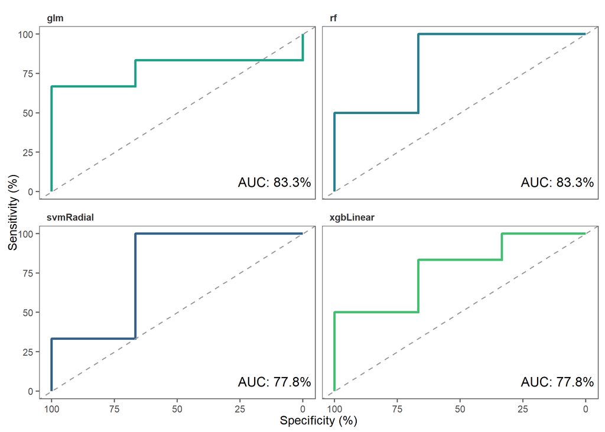

```r
roc_plot(
  probability_list = covid_prob_list,
  split_df = covid_split_df
)
```

### Tutorials

You can choose a tutorial from the list below that best fits your experiment and the structure of your proteomics data.

1. If your data do NOT contain technical replicates: [promor: No technical replicates](https://caranathunge.github.io/promor/articles/promor_no_techreps.html)
2. If your data contains technical replicates: [promor: Technical replicates](https://caranathunge.github.io/promor/articles/promor_with_techreps.html)
3. If you would like to use your proteomics data to build predictive models: [promor: Modeling](https://caranathunge.github.io/promor/articles/promor_for_modeling.html)